# Etap V

# 6.Efekt czytania czasopism naukowych i wykształcenia ojca

Czytanie czasopism naukowych pozytywnie wpływa na czas rozwiązywania zadań w przypadku maksymalnie średniego wykształcenia ojca, a im częściej uczeń czyta tym krótszy czas rozwiązania. Uczniowie, nie czytający prawie wcale, wyraźnie więcej czasu spędzają nad pojedyńczym zadaniem. W przypadku gdy ojciec ma wykształcenie wyższe tendecja jest pomijalnie rosnącą w stosunku do częstości czytania, czyli nie ma wpływu.

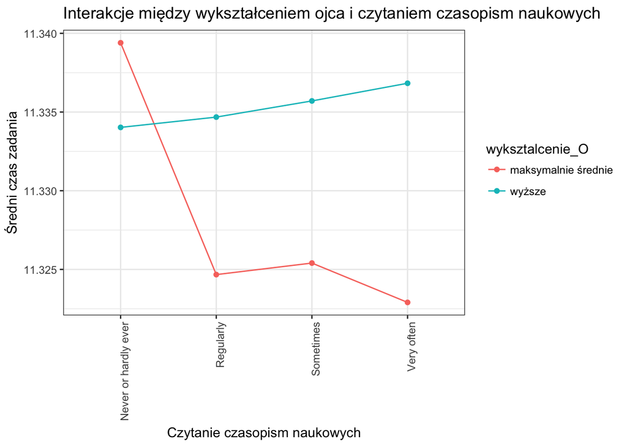

```r
daneCO<-cbind(dane$CNTSTUID, as.vector(as.character(dane$question_time)), as.character(dane$czytanieCzasopismNaukowych), dane$wyksztalcenie_O)
colnames(daneCO)<-c("CNTSTUID", "question_time", "czytanieCzasopismNaukowych", "wyksztalcenie_O")
daneCO<-as.data.frame(na.omit(daneCO))
daneCO<-daneCO[daneCO$czytanieCzasopismNaukowych!="No Response",]
daneCO<-daneCO[!daneCO$wyksztalcenie_O == "brak danych", ]

int1 <- ddply(daneCO,.(czytanieCzasopismNaukowych,wyksztalcenie_O),summarise, val = mean(log(as.numeric(question_time))))

ggplot(daneCO, aes(x = factor(czytanieCzasopismNaukowych), y = log(question_time), colour = wyksztalcenie_O)) +
    geom_point(data = int1, aes(y = val)) +
    geom_line(data = int1, aes(y = val, group = wyksztalcenie_O)) +
    theme_bw()+
    theme(axis.text.x = element_text(angle = 90, hjust = 1))+
    xlab("Czytanie czasopism naukowych")+
    ylab("Średni czas zadania")+
    ggtitle("Interakcje między wykształceniem ojca i czytaniem czasopism naukowych")
```

#7.Efekt czytania czasopism naukowych i wykształcenia matki Dla maksymalnie średniego wykształcenia matki czas rozwiązywania zadania jest znącząco krótszy gdy uczeń czyta czasopisma względem gdy nie czyta wcale.

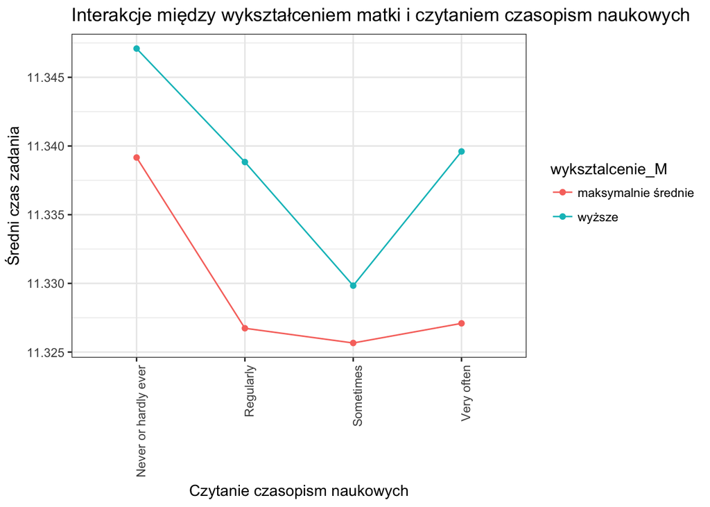

```r
daneCM<-cbind(dane$CNTSTUID, as.vector(as.character(dane$question_time)), as.character(dane$czytanieCzasopismNaukowych), dane$wyksztalcenie_M)
colnames(daneCM)<-c("CNTSTUID", "question_time", "czytanieCzasopismNaukowych", "wyksztalcenie_M")
daneCM<-as.data.frame(na.omit(daneCM))
daneCM<-daneCM[daneCM$czytanieCzasopismNaukowych!="No Response",]
daneCM<-daneCM[!daneCM$wyksztalcenie_M == "brak danych", ]

int1 <- ddply(daneCM,.(czytanieCzasopismNaukowych,wyksztalcenie_M),summarise, val = mean(log(as.numeric(question_time))))

ggplot(daneCM, aes(x = factor(czytanieCzasopismNaukowych), y = log(question_time), colour = wyksztalcenie_M)) +
    geom_point(data = int1, aes(y = val)) +
    geom_line(data = int1, aes(y = val, group = wyksztalcenie_M)) +
    theme_bw()+
    theme(axis.text.x = element_text(angle = 90, hjust = 1))+
    xlab("Czytanie czasopism naukowych")+
    ylab("Średni czas zadania")+
    ggtitle("Interakcje między wykształceniem matki i czytaniem czasopism naukowych")
```

# 8.Efekt wykształcenia ojca i matki

Wykształcenie ojca na poziomie wyższym przekłada się na krótszy czas poświęcany na zadanie. Na wykresie widoczne jest przecięcie, co oznacza interakcję pomiędzy wykształceniem ojca i matki.

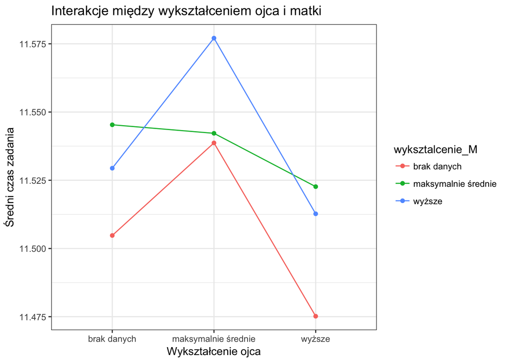

```r
int1 <- ddply(dane,.(wyksztalcenie_O,wyksztalcenie_M),summarise, val = mean(log(as.numeric(question_time))))

ggplot(dane, aes(x = factor(wyksztalcenie_O), y = log(question_time), colour = wyksztalcenie_M)) +
    geom_point(data = int1, aes(y = val)) +
    geom_line(data = int1, aes(y = val, group = wyksztalcenie_M)) +
    theme_bw()+
    theme(axis.text.x = element_text(angle = 0, hjust = 0.5))+
    xlab("Wykształcenie ojca")+
    ylab("Średni czas zadania")+
    ggtitle("Interakcje między wykształceniem ojca i matki")
```

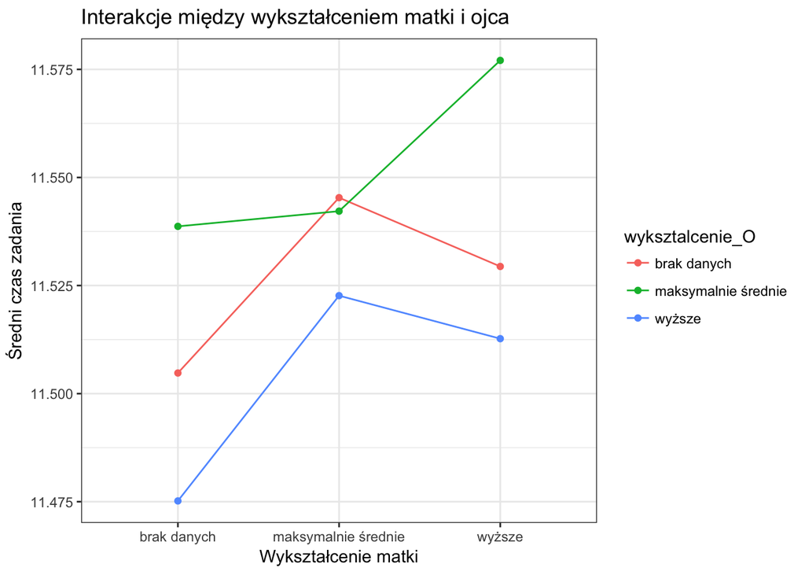

```r
int1 <- ddply(dane,.(wyksztalcenie_M,wyksztalcenie_O),summarise, val = mean(log(as.numeric(question_time))))

ggplot(dane, aes(x = factor(wyksztalcenie_M), y = log(question_time), colour = wyksztalcenie_O)) +
    geom_point(data = int1, aes(y = val)) +
    geom_line(data = int1, aes(y = val, group = wyksztalcenie_O)) +
    theme_bw()+
    theme(axis.text.x = element_text(angle = 0, hjust = 0.5))+
    xlab("Wykształcenie matki")+
    ylab("Średni czas zadania")+
    ggtitle("Interakcje między wykształceniem matki i ojca")
```

# 9. Zbadanie istotności interakcji w modelu

W celu zbadania istotności znalezionych powyżej interakcji, modyfikujemy nasz model z poprzednich etapów. Wykonujemy analizę wariancji dla zmodyfikowanego modelu i sprawdzamy istotnośćrozważanych interakcji.

```r
model<-(lm(log(question_time)~position*item+jezyk+kraj+plec+wyksztalcenie_M*wyksztalcenie_O+czytanieCzasopismNaukowych, data=dane))

anova(model)
```

```
## Analysis of Variance Table
##
## Response: log(question_time)
##                                     Df Sum Sq Mean Sq   F value    Pr(>F)
## position                             3   6658 2219.23 5285.3138 < 2.2e-16
## item                                40  89110 2227.75 5305.6139 < 2.2e-16
## jezyk                                4   8686 2171.47 5171.5733 < 2.2e-16
## kraj                                11   1106  100.57  239.5150 < 2.2e-16
## plec                                 1     82   82.22  195.8183 < 2.2e-16
## wyksztalcenie_M                      2    171   85.55  203.7340 < 2.2e-16
## wyksztalcenie_O                      2     46   23.10   55.0260 < 2.2e-16
## czytanieCzasopismNaukowych           4    119   29.67   70.6708 < 2.2e-16
## position:item                      120   1339   11.16   26.5689 < 2.2e-16
## wyksztalcenie_M:wyksztalcenie_O      4     11    2.78    6.6199 2.533e-05
## Residuals                       437674 183773    0.42
##
## position                        ***
## item                            ***
## jezyk                           ***
## kraj                            ***
## plec                            ***
## wyksztalcenie_M                 ***
## wyksztalcenie_O                 ***
## czytanieCzasopismNaukowych      ***
## position:item                   ***
## wyksztalcenie_M:wyksztalcenie_O ***
## Residuals
## ---
## Signif. codes:  0 '***' 0.001 '**' 0.01 '*' 0.05 '.' 0.1 ' ' 1
```